# Fitting consumer resource - PROC model

Author

Benjamin Rosenbaum

## Model

The Rosenzweig-MacArthur predator-prey model with logistic growth and Type II functional response reads

$$\begin{aligned}
\frac{dN_1}{dt} &= r(1-\frac{N_1}{K})N_1 -\frac{ahN_1}{1+ahN_1}N_2 \\
\frac{dN_2}{dt} &= e\frac{ahN_1}{1+ahN_1}N_2 -d N_2
\end{aligned}$$

Using one-step-ahead fitting (process error only), we will fit all datapoints $(N_{1,t},N_{2,t})$ of $m$ 2-species timeseries replicates with predictions based on their previous observations $(N_{1,t-1},N_{2,t-1})$. A joint set of model parameters $r,K,a,h,e,d$ (“complete pooling”) is used.

Additionally, we fit trajectories for $m_c$ control (single-species) time series of prey ($N_2=0$, logistic growth)
$$\frac{dN_1}{dt} = r(1-\frac{N_1}{K})N_1$$
and $m_c$ control time series of predator ($N_1=0$, exponential decline)
$$\frac{dN_2}{dt} = -dN_2$$
These control data will provide additional information on $r,K$ and $d$.

## Data preparation

The dataset `data_example_consumer_resource.csv` contains `m=6` timeseries with `n=18` observations of densities [ind] each, including their dates [h]. The fraction of the observed volume for sampling was `f=0.1`. Data preparation is identical to the OBS model manual.

```r
rm(list=ls())
library("rstan")
```

```r
data.in = read.csv("data_example_consumer_resource.csv", row.names=1)

head(data.in)
```

```
      X1  X2  X3  X4  X5   X6   X7   X8   X9 X10 X11 X12  X13  X14  X15  X16
time   0  12  24  36  48   60   72   96  120 144 168 192  216  240  264  288
N1   200 207 228 370 664  958 1330 1253 1017 827 546 276  240  409 1094 1452
N2   189 205 283 461 716 1002 1212 1032  610 227 245 600 1128 1383 1330  862
N3   201 222 280 394 595  822 1097 1097  779 422 303 431 1001 1439 1161  912
N4   198 214 241 428 641  924 1281 1413 1261 736 288 214  361  761 1168 1036
N5   191 204 274 483 772 1060 1251 1100  688 333 267 612 1320 1595 1542 1128
      X17 X18
time  312 336
N1   1291 903
N2    329 119
N3    400 146
N4    596 285
N5    817 389
```

```r
n = 18
m = 6
mc = 3

times = as.numeric(data.in[1, ])
N1 = unname(as.matrix(data.in[2:(m+1), ]))
N2 = unname(as.matrix(data.in[(m+2):(2*m+1), ]))
N1C = unname(as.matrix(data.in[(2*m+2):(2*m+1+mc), ]))
N2C = unname(as.matrix(data.in[(2*m+2+mc):((2*m+1+2*mc)), ]))

data = list(n = n,
            m = m,
            mc = mc,
            t = times,
            N1 = N1,
            N2 = N2,
            N1C  = N1C,
            N2C  = N2C,
            f=0.1)

str(data)
```

```
List of 9
 $ n  : num 18
 $ m  : num 6
 $ mc : num 3
 $ t  : num [1:18] 0 12 24 36 48 60 72 96 120 144 ...
 $ N1 : int [1:6, 1:18] 200 189 201 198 191 174 207 205 222 214 ...
 $ N2 : int [1:6, 1:18] 48 38 41 42 56 40 35 29 27 34 ...
 $ N1C: int [1:3, 1:18] 40 51 51 96 144 117 259 370 411 637 ...
 $ N2C: int [1:3, 1:18] 195 185 201 104 98 105 58 56 44 40 ...
 $ f  : num 0.1
```

## Stan model

The Stan model is coded as a string, which is compiled later. A step by step walkthrough is given below.

```r
stanmodelcode="
functions{
  vector odemodel(real t, vector N, vector p){
    // p[1]=r, p[2]=K, p[3]=b, p[4]=h, p[5]=e, p[6]=d
    vector[2] dNdt;
    dNdt[1] = p[1]*N[1]*(1.0-N[1]/p[2])-p[3]*N[1]*N[2]/(1.0+p[3]*p[4]*N[1]);
    dNdt[2] = p[5]*p[3]*N[1]*N[2]/(1.0+p[3]*p[4]*N[1])-p[6]*N[2];
    return dNdt;
  }
}

data{
  int n; // observations
  int m; // replicates
  int mc; // replicates control
  real t[n];
  array[m,n] int N1;
  array[m,n] int N2;
  array[mc,n] int N1C;
  array[mc,n] int N2C;
  real f;
}

parameters{
  real<lower=0> r;
  real<lower=0> K;
  real<lower=0> b;
  real<lower=0> h;
  real<lower=0, upper=1> e;
  real<lower=0> d;
  vector<lower=0>[2] tau;
}

model{
  vector[6] p;
  array[1] vector[2] Nsim; // simulated values, matrix. dim1 = 1 point in time, dim2 = dim_ODE = 2
  array[1] vector[1] NCsim; // simulated values, matrix. dim1 = 1 point in time, dim2 = dim_ODE = 1

  // priors
  r ~ lognormal(-2,1);
  K ~ lognormal(9,1);
  b ~ gamma(2,1);
  h ~ gamma(2,1);
  // e ~ gamma(2,1);
  d ~ gamma(2,1);
  tau ~ gamma(2,0.1);

  //---------------------------------------------------------------------------
  // 2-species data
  //---------------------------------------------------------------------------

  // parameters for integrator
  p[1] = r;
  p[2] = K;
  p[3] = b;
  p[4] = h;
  p[5] = e;
  p[6] = d;

  for(j in 1:m){
    for(i in 1:(n-1)){
      // integrate ODE
      Nsim = ode_rk45(odemodel, [N1[j,i]/f,N2[j,i]/f]', t[i], {t[i+1]}, p);
      // likelihood
      if(N1[j,i]>0){
        N1[j,i+1] ~ neg_binomial_2(Nsim[1,1]*f,tau[1]);
      }
      if(N2[j,i]>0){
        N2[j,i+1] ~ neg_binomial_2(Nsim[1,2]*f,tau[2]);
      }
    }
  }

  //---------------------------------------------------------------------------
  // resource: control data
  //---------------------------------------------------------------------------

  for (j in 1:mc){
    for(i in 1:(n-1)){
      if(N1C[j,i]>0){
        // integrate ODE
        NCsim[1,1] = K/( 1.0+(K-N1C[j,i]/f)/(N1C[j,i]/f) * exp(-r*(t[i+1]-t[i]))); // analytical solution
        // likelihood
        N1C[j,i+1] ~ neg_binomial_2(NCsim[1,1]*f,tau[1]);
      }
    }
  }

  //---------------------------------------------------------------------------
  // consumer: control data
  //---------------------------------------------------------------------------

  for (j in 1:mc){
    for(i in 1:(n-1)){
      if(N2C[j,i]>0){
        // integrate ODE
        NCsim[1,1] = N2C[j,i]/f * exp(-d*(t[i+1]-t[i])); // analytical solution
        // likelihood
        N2C[j,i+1] ~ neg_binomial_2(NCsim[1,1]*f,tau[2]);
      }
    }
  }

}
"
```

### functions{ } block

This is identical to the OBS model manual.

```
  vector odemodel(real t, vector N, vector p){
    // p[1]=r, p[2]=K, p[3]=b, p[4]=h, p[5]=e, p[6]=d
    vector[2] dNdt;
    dNdt[1] = p[1]*N[1]*(1.0-N[1]/p[2])-p[3]*N[1]*N[2]/(1.0+p[3]*p[4]*N[1]);
    dNdt[2] = p[5]*p[3]*N[1]*N[2]/(1.0+p[3]*p[4]*N[1])-p[6]*N[2];
    return dNdt;
  }
```

### data{ } block

This is identical to the OBS model manual.

```
  int n; // observations
  int m; // replicates
  int mc; // replicates control
  real t[n];
  array[m,n] int N1;
  array[m,n] int N2;
  array[mc,n] int N1C;
  array[mc,n] int N2C;
  real f;
```

### parameters{ } block

Here, all free parameters are declared. This includes model parameters `r`,`K`,`b`,`h`,`e`,`d` and 2 parameters `tau` (for prey and predator observations, respectively) for the residual distribution (overdispersion of the negative binomial).

```
  real<lower=0> r;
  real<lower=0> K;
  real<lower=0> b;
  real<lower=0> h;
  real<lower=0, upper=1> e;
  real<lower=0> d;
  vector<lower=0>[2] tau;
```

### model{ } block

This block defines how the posterior computed, using prior distributions and the likelihood function. First, some intermediate variables for the ODE simulation are declared. `p` is a vector which stores all 6 model parameters. `Nsim` will contain the output of the numerical integration with dimensions `1` (predict only next state), and the second dimension is number of states (2). This array-vector combination is required with the ODE solver function. `NCsim` will contain predictions for single species control time series, so only 1 state.

```
  vector[6] p;
  array[1] vector[2] Nsim; // simulated values, matrix. dim1 = 1 point in time, dim2 = dim_ODE = 2
  array[1] vector[1] NCsim; // simulated values, matrix. dim1 = 1 point in time, dim2 = dim_ODE = 1
```

Priors: This is identical to the OBS model manual.

[output not shown]

After the priors are defined, predictions are computed. We start with the 2-species mixtures, and then single species time series for prey and predator (control data).

For the 2-species time series, predictions are computed via numerically integrating the ODE, which requires all model parameters are stored in one array `p`.

```
  //---------------------------------------------------------------------------
  // 2-species data
  //---------------------------------------------------------------------------

  // parameters for integrator
  p[1] = r;
  p[2] = K;
  p[3] = b;
  p[4] = h;
  p[5] = e;
  p[6] = d;
```

In a loop over all `m` time series replicates and `n-1` timepoints, numerical integration is performed, to predict the next state (`N1[j,i+1]`,`N2[j,i+1]`) from the current state (`N1[j,i]`,`N2[j,i]`). Observed data is abundance in sampling fraction `f`, so the initial values are scaled up to the total volume (`N1[j,i]/f`,`N2[j,i]/f`) for numerical integration, and predictions are scaled down later to the sampling fraction (`Nsim[,]*f`) for calculating residuals. The integration routine `ode_rk45()` is must be called in a specific format. Arguments are the function `odemodel` as defined in the `functions{}` block. The initial state is converted to an array using `[ ]'`. Integration is performed from `t[i]` to `t[i+1]`. `p` contains the model parameters.

After computing the predicted state `Nsim` (in `t[i+1]`), it is confronted with the data (`N1[j,i+1]`,`N2[j,i+1]`): : a negative binomial distribution defines likelihood values. Since the data was sampled in a fraction `f=0.1`, the distribution’s mean is `Nsim[,]*f`, with some overdispersion `tau`.

The prey prediction is only added to the likelihood if `N1[j,i]>0`. `N1[j,i]=0` would predict a 0 in `t[i+1]` irrespective of the model parameters, so it wouldn’t contribute any information to the likelihood function. Same applies for predator osbervations `N2[j,i]` and their predictions.

```
  for(j in 1:m){
    for(i in 1:(n-1)){
      // integrate ODE
      Nsim = ode_rk45(odemodel, [N1[j,i]/f,N2[j,i]/f]', t[i], {t[i+1]}, p);
      // likelihood
      if(N1[j,i]>0){
        N1[j,i+1] ~ neg_binomial_2(Nsim[1,1]*f,tau[1]);
      }
      if(N2[j,i]>0){
        N2[j,i+1] ~ neg_binomial_2(Nsim[1,2]*f,tau[2]);
      }
    }
  }
```

Next, we compute one-step-ahead predictions for the single species prey time series (control data). They follow logistic growth, so we can compute them analytically, i.e. with a direct formula instead of numerical integration:

$$\widehat{N}_1(t_{i+1})=\frac{K}{ 1+\frac{K-N_{1,i}}{N_{1,i}}e^{-r(t_{i+1}-t_{i})} }$$
This is generally faster than performing numerical integration. If no analytical formulation is available, numerical integration has to be performed by either using the same ODE function as above with initial values `[N1C[j,i], 0]'`, or by coding a separate function for the single-species growth model.

```
  //---------------------------------------------------------------------------
  // resource: control data
  //---------------------------------------------------------------------------

  for (j in 1:mc){
    for(i in 1:(n-1)){
      if(N1C[j,i]>0){
        // integrate ODE
        NCsim[1,1] = K/( 1.0+(K-N1C[j,i]/f)/(N1C[j,i]/f) * exp(-r*(t[i+1]-t[i]))); // analytical solution
        // likelihood
        N1C[j,i+1] ~ neg_binomial_2(NCsim[1,1]*f,tau[1]);
      }
    }
  }
```

Finally, we do the same for the single species predator time series (control data). They follow exponential decline with an analytical solution

$$\widehat{N}_2(t_{i+1})=N_{2,i}e^{-d(t_{i+1}-t_{i})}$$

Again, if no analytical formulation is available, numerical integration has to be performed by either using the same ODE function as above with initial values `[0, N2C[j,i]]'`, or by coding a separate function for the single-species predator model.

```
  //---------------------------------------------------------------------------
  // consumer: control data
  //---------------------------------------------------------------------------

  for (j in 1:mc){
    for(i in 1:(n-1)){
      if(N2C[j,i]>0){
        // integrate ODE
        NCsim[1,1] = N2C[j,i]/f * exp(-d*(t[i+1]-t[i])); // analytical solution
        // likelihood
        N2C[j,i+1] ~ neg_binomial_2(NCsim[1,1]*f,tau[2]);
      }
    }
  }
```

## Model fitting

This is identical to the OBS model manual.

```r
# stan options
chains = 3
rstan_options(auto_write = TRUE)
options(mc.cores = chains)
iter   =  4000
warmup =  2000
```

Then starting values for all free parameters are provided as a list (in case of multiple chains: a list of lists). Remaining parameters are given guesses. Stan usually converges quickly towards the parameter region featuring a high probability density. But with ODEs involved, good initial guesses that do not cause numerical issues in ODE integration are often required.

```r
# initial values for sampling
init=rep(list(list(r=0.1,
                   K=2e4,
                   b=0.0003,
                   h=0.5,
                   e=0.1,
                   d=0.1,
                   tau=c(10,10)
))
,chains)
```

Finally, the model is compiled and sampling is started.

```r
stanmodel = stan_model(model_code=stanmodelcode)

fit = sampling(stanmodel,
               data=data,
               iter=iter,
               warmup=warmup,
               chains=chains,
               init=init
)
```

## Model diagnostics

Convergence of the MCMC chains is checked, e.g. by looking at estimated model parameters. We check the effective sample size `n_eff` and the Gelman-Rubin diagnostics `Rhat` (should be <1.01), indicating that chains have mixed.

```r
print(fit, digits=3, pars=c("r","K","b","h","e","d","tau"), probs=c(0.025, 0.5, 0.975))
```

```
Inference for Stan model: anon_model.
3 chains, each with iter=4000; warmup=2000; thin=1;
post-warmup draws per chain=2000, total post-warmup draws=6000.

            mean se_mean      sd      2.5%       50%     97.5% n_eff  Rhat
r          0.091   0.000   0.003     0.085     0.091     0.098  3012 1.000
K      19909.749   8.672 513.923 18919.611 19903.594 20986.202  3512 1.000
b          0.000   0.000   0.000     0.000     0.000     0.000  2472 1.000
h          0.554   0.001   0.041     0.474     0.553     0.636  2512 1.000
e          0.052   0.000   0.005     0.043     0.052     0.062  2338 1.001
d          0.047   0.000   0.004     0.040     0.047     0.054  2457 1.001
tau[1]    42.162   0.069   5.242    32.595    41.928    53.258  5694 1.000
tau[2]    40.818   0.164  10.856    23.987    39.256    66.188  4399 1.000

Samples were drawn using NUTS(diag_e) at Fri Jan 26 10:24:47 2024.
For each parameter, n_eff is a crude measure of effective sample size,
and Rhat is the potential scale reduction factor on split chains (at
convergence, Rhat=1).
```

Additionally, chains are inspected visually via trace- and density plots.

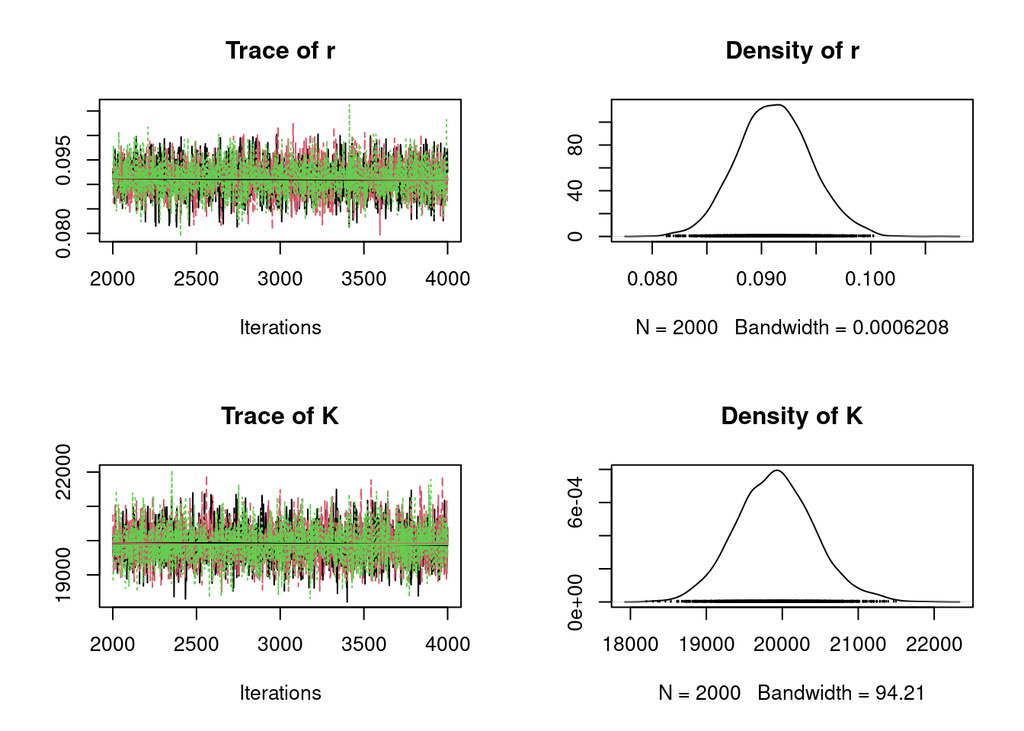

```r
library("coda")
samples=As.mcmc.list(fit)
plot(samples[, c("r","K","b","h","e","d")])
```

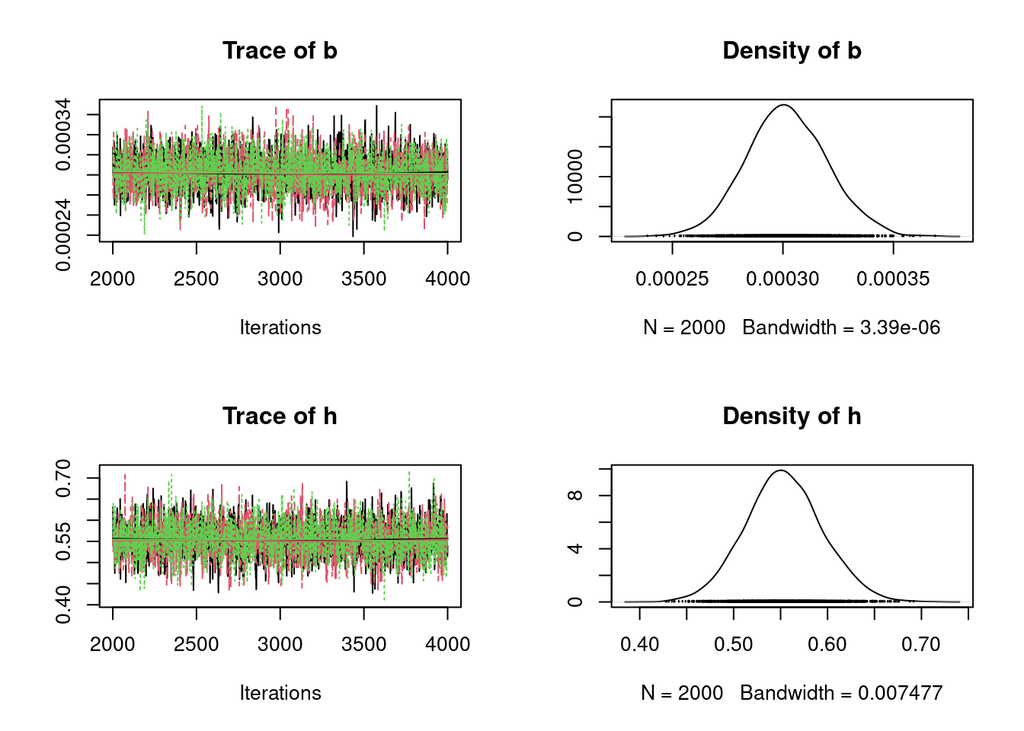

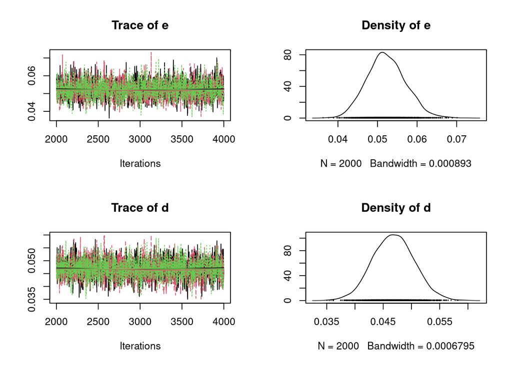

A pairs plot can detect correlations in model parameters. Almost perfect correlation would indicate non-identifiability.

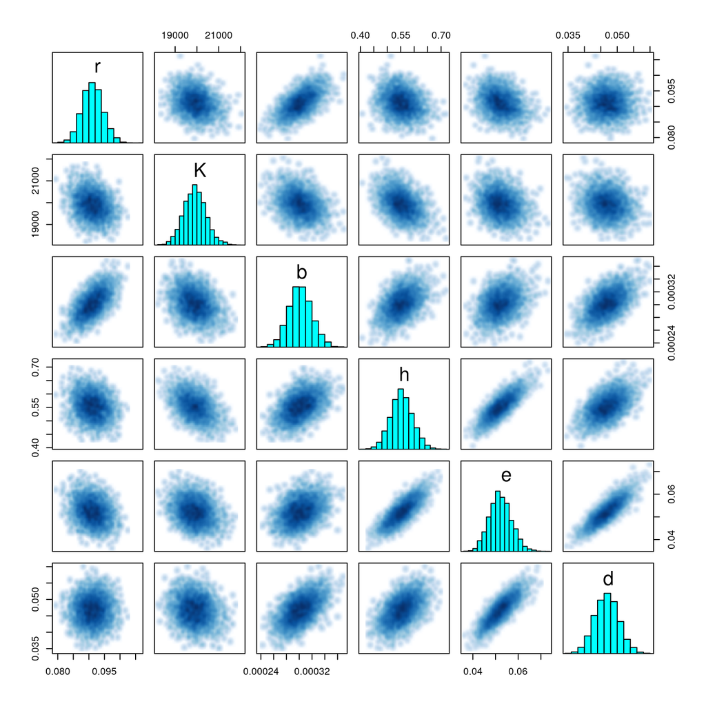

```r
pairs(fit, pars=c("r","K","b","h","e","d"))
```

## Posterior predictions

Posterior predictions are generated one-step-ahead from sampled posterior parameters. Alternatively, this can be done while sampling using `generated quantities{}` block in the model code. Here, we use the `deSolve` package for numerical integration to compute posterior predictions. First, we code an R function defining the population growth rate (ODE).

```r
library("deSolve")
ode.model = function(t,N,p){
  dN1dt = p[1]*N[1]*(1.0-N[1]/p[2])-p[3]*N[1]*N[2]/(1.0+p[3]*p[4]*N[1])
  dN2dt = p[5]*p[3]*N[1]*N[2]/(1.0+p[3]*p[4]*N[1])-p[6]*N[2]
  return(list(c(dN1dt,dN2dt)))
}
```

Samples of the posterior distribution are converted to matrix. Each column contains all samples of a single parameter, while each row contains one sample from the multivariate posterior distribution.

```r
post = as.matrix(fit)
# head(post)
n.post = 1000 # nrow(post)
```

The empty matrices `N1.pred` and `N2.pred`(prey and predator) will store all predicted values: each row will contain one sample of a predicted timeseries. Predictions are computed for each time series replicate (for-loop over `i`) and each timepoint (for-loop over `k`) separately. For each sample from the posterior (row `j` in matrix `post[j, ]`), each prediction is computed by numerically integrating the ODE, starting in the last observation (`data$N1[i,k]/data$f`,`data$N1[i,k]/data$f`, scaled up to the total volume). Each column `k` of `N1.pred[ ,k]`/`N2.pred[ ,k]` contains posterior predictions in `t[k+1]`. We calculate quantiles of these predictions and plot them against the data.

Here, we only show the 2-species mixtures and omit the control time series.

Since these are one-step-ahead predictions from the last observation, we plot them pointwise in time, rather than a trajectory as in the OBS model.

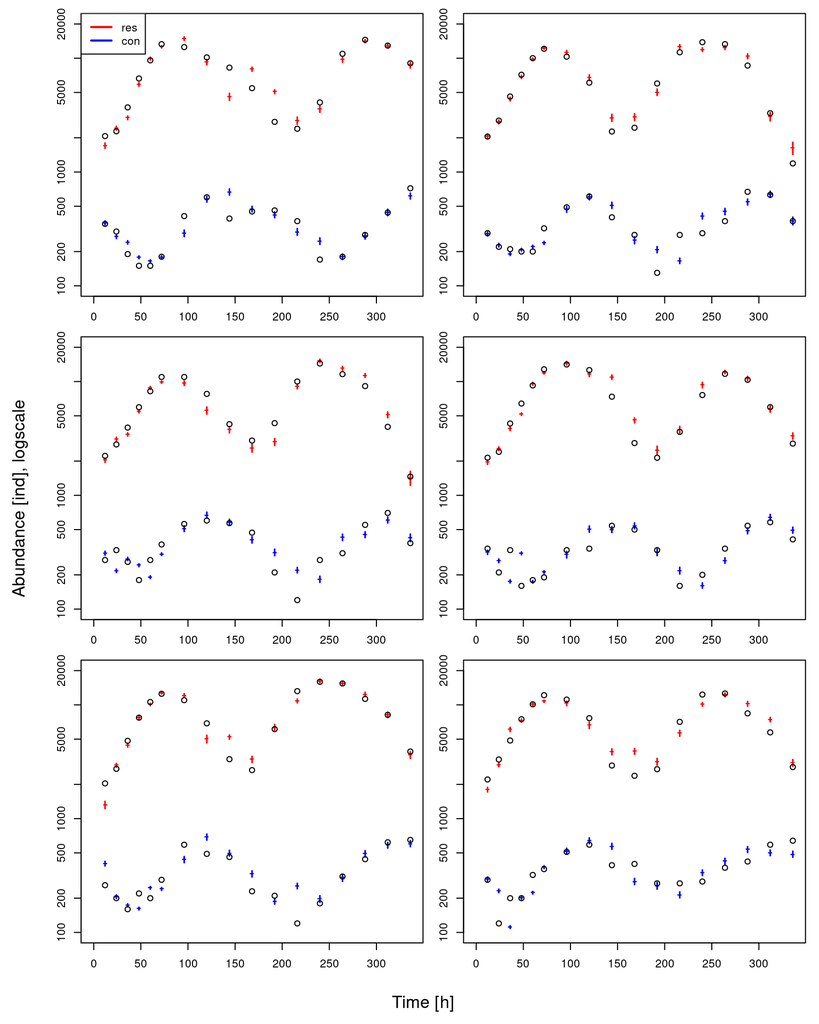

```r
par(mfrow=c(3,2), mar=c(3,3,0,0), oma=c(3,3,1,1))

for(i in 1:6){

  N1.pred = matrix(NA, nrow=n.post, ncol=length(data$t)-1)
  N2.pred = matrix(NA, nrow=n.post, ncol=length(data$t)-1)

  for(j in 1:n.post){
    for(k in 1:(length(data$t)-1)){
      Ns = as.data.frame(lsoda(y     = c( N = c(data$N1[i,k]/data$f,data$N2[i,k]/data$f) ),
                               times = data$t[c(k,k+1)],
                               func  = ode.model,
                               parms = c(post[j, c("r","K","b","h","e","d")])
      ))[2, 2:3]
      N1.pred[j,k] = as.numeric(Ns[1])
      N2.pred[j,k] = as.numeric(Ns[2])
    }
  }

  N1.pred.qs = apply(N1.pred, 2, function(x) quantile(x, probs=c(0.025,0.500,0.975), na.rm=TRUE))
  N2.pred.qs = apply(N2.pred, 2, function(x) quantile(x, probs=c(0.025,0.500,0.975), na.rm=TRUE))

  plot(c(data$t,data$t), c(data$N1[i, ]/data$f,data$N2[i, ]/data$f),
       ylim=c(1e2,2e4), type="n", xlab="", ylab="", log="y")

  for(k in 1:(n-1)){
    lines(c(data$t[k+1],data$t[k+1]), c(N1.pred.qs[1,k],N1.pred.qs[3,k]), col="red", lwd=1.5)
  }
  points((data$t[2:n]), N1.pred.qs[2, ], col="red", pch="-", cex=1.5)
  points((data$t[2:n]), (data$N1[i,2:n]/data$f), type="p")

  for(k in 1:(n-1)){
    lines(c(data$t[k+1],data$t[k+1]), c(N2.pred.qs[1,k],N2.pred.qs[3,k]), col="blue", lwd=1.5)
  }
  points(as.numeric(data$t[2:n]), N2.pred.qs[2, ], col="blue", pch="-", cex=1.5)
  points((data$t[2:n]), (data$N2[i,2:n]/data$f), type="p")

  if(i==1) legend("topleft", c("res","con"), lwd=c(2,2), col=c("red","blue"))
}
mtext("Time [h]", side=1, outer=TRUE, line=1)
mtext("Abundance [ind], logscale", side=2, outer=TRUE, line=1)
```